# Reproducible Research Week2 Course Project 1

PL

2022-07-04

## R Markdown

This assignment makes use of data from a personal activity monitoring device. This device collects data at 5 minute intervals through out the day. The data consists of two months of data from an anonymous individual collected during the months of October and November, 2012 and include the number of steps taken in 5 minute intervals each day.

```r
library(ggplot2)
library(dplyr)
library(lubridate)
library(magrittr)
```

## 1. Code for reading in the dataset and/or processing the data

Unzip the file

```r
path <- getwd()
unzip ("repdata_data_activity.zip", exdir=path)

# read the data to file and see the summary of the data
Activity <- read.csv("activity.csv")
summary(Activity)
```

```
##      steps            date              interval
##  Min.   :  0.00   Length:17568       Min.   :   0.0
##  1st Qu.:  0.00   Class :character   1st Qu.: 588.8
##  Median :  0.00   Mode  :character   Median :1177.5
##  Mean   : 37.38                      Mean   :1177.5
##  3rd Qu.: 12.00                      3rd Qu.:1766.2
##  Max.   :806.00                      Max.   :2355.0
##  NA's   :2304
```

```r
names(Activity)
```

```
## [1] "steps"    "date"     "interval"
```

```r
head(Activity)
```

```
##   steps       date interval
## 1    NA 2012-10-01        0
## 2    NA 2012-10-01        5
## 3    NA 2012-10-01       10
## 4    NA 2012-10-01       15
## 5    NA 2012-10-01       20
## 6    NA 2012-10-01       25
```

## 2. Histogram of the total number of steps taken each day

Count total number of steps taken per day

```r
total_steps <- Activity %>%
  group_by(date) %>%
  summarise(daily_steps = sum(steps, na.rm = TRUE))
```

Histogram of the total number of steps taken each day

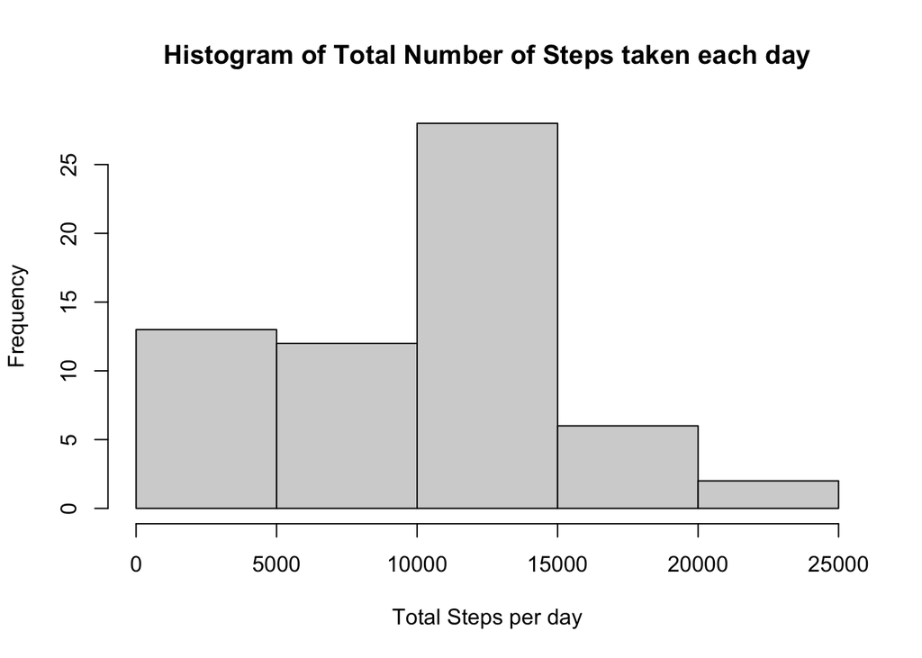

```r
hist(total_steps$daily_steps, xlab = "Total Steps per day", main = "Histogram of Total Number of Steps taken each day")
```

## 3. Mean and median number of steps taken each day

```r
meanStep = mean(total_steps$daily_steps, na.rm=TRUE)
medianStep = median(total_steps$daily_steps, na.rm=TRUE)

# The Mean number of steps taken each day are
meanStep
```

```
## [1] 9354.23
```

```r
# The Median number of steps taken each day are
medianStep
```

```
## [1] 10395
```

## 4. Time series plot of the average number of steps taken

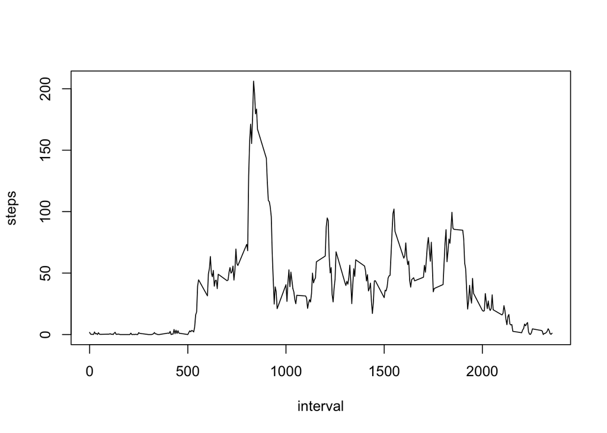

```r
interval_steps <- Activity %>%
  group_by(interval) %>%
  summarise(steps = mean(steps, na.rm =TRUE))

plot(steps~interval, data=interval_steps, type="l")
```

```r
max_interval_steps <- interval_steps[which.max(interval_steps$steps),]$interval
```

## 6. Code to describe and show a strategy for imputing missing data

```r
totalNA<- sum(is.na(Activity$steps))
```

Total number of missing values is 2304.

Devise a strategy for filling in all of the missing values in the dataset. The strategy does not need to be sophisticated. For example, you could use the mean/median for that day, or the mean for that 5-minute interval, etc.

```r
interval_steps_mean <- function(interval){
    interval_steps[interval_steps$interval==interval,]$steps
}
```

Create a new dataset that is equal to the original dataset but with the missing data filled in.

```r
ActivityNoNA <- Activity
for(i in 1:nrow(ActivityNoNA)){
    if(is.na(ActivityNoNA[i,]$steps)){
        ActivityNoNA[i,]$steps <- interval_steps_mean(ActivityNoNA[i,]$interval)
    }
}
```

## 7. Histogram of the total number of steps taken each day after missing values are imputed

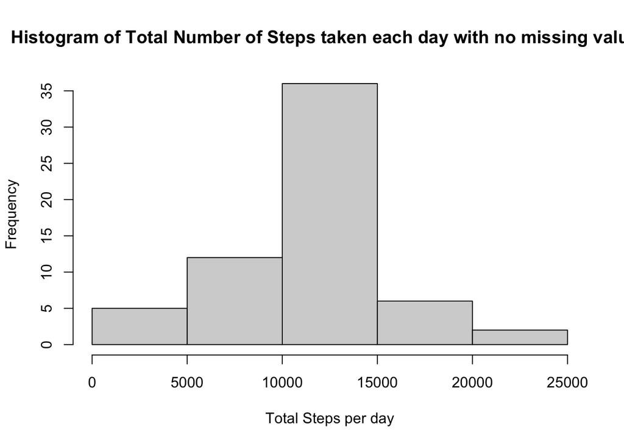

```r
daily_steps_NoNA <- aggregate(steps ~ date, data=ActivityNoNA, sum)
hist(daily_steps_NoNA$steps, xlab = "Total Steps per day", main = "Histogram of Total Number of Steps taken each day with no missing values")
```

```r
meanStepNoNA <- mean(daily_steps_NoNA$steps)
medianStepNoNA <- median(daily_steps_NoNA$steps)

# The median steps without missing value are
meanStepNoNA
```

```
## [1] 10766.19
```

```r
# The median steps without missing value are
medianStepNoNA
```

```
## [1] 10766.19
```

```r
mean_diff <- meanStepNoNA - meanStep
median_diff <- medianStepNoNA - medianStep

# The mean steps difference between data with and without missing values are
mean_diff
```

```
## [1] 1411.959
```

```r
# The median steps difference between data with and without missing values are
median_diff
```

```
## [1] 371.1887
```

## 8. Panel plot comparing the average number of steps taken per 5-minute interval across weekdays and weekends

```r
day_of_week <- ActivityNoNA %>%
  mutate(
    date = ymd(date),
    weekday_or_weekend = case_when(wday(date) %in% 2:6 ~ "Weekday",
                                   wday(date) %in% c(1,7) ~ "Weekend")
  ) %>% select(-date) %>%
  group_by(interval, weekday_or_weekend) %>%
  summarise(
    steps = mean(steps)
  )
```

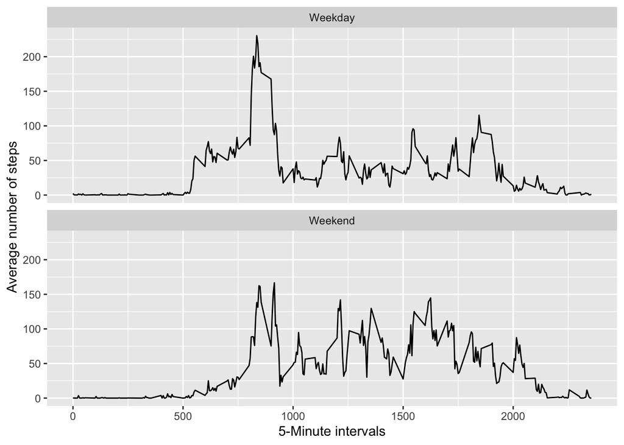

```r
# Creating the data set that to plot

ggplot(day_of_week, aes(interval, steps))  +
    geom_line()  +
    facet_wrap(~weekday_or_weekend, nrow = 2) +
    xlab("5-Minute intervals")  +
    ylab("Average number of steps")
```